# Prestudy Report

sasha popov

2024-10-14

## 1. Demographic Data (Exploratry Data Analysis, a.k.a. Overview)

```r
library(tidyverse)
library(gt)
source("analysfunc.R")
df_act = compose_df("user") |>
  mutate(timestamp = ymd_hms(timestamp))
resp = elicit_respondents(df_act, no_timestamp = FALSE) |>
  left_join(institute_lookup, by = c("subj" = "dep")) |>
  na.omit()
```

Overall participants:

```r
print(nrow(resp))
```

```
## [1] 184
```

- `age` - age.
- `gender` (with ability to enter gender if non-binary).
- `subj` - department of the student’s program/major.
- `edu_year` - amount of years in the university.
- `occup` - amount of years in Norway.
- `family_acad` - highest degree of parents.
- `orient`- sexual orientation.

```r
resp |> head()
```

```
## # A tibble: 6 × 11
##   timestamp           id            age   gender gender_oth subj  edu_year occup
##   <dttm>              <chr>         <chr> <chr>  <chr>      <chr> <chr>    <chr>
## 1 2024-09-26 20:40:17 034010ca-4d6… 21    female ""         Depa… 2        21
## 2 2024-09-30 11:01:02 04e683b9-5e1… 20    male   ""         Depa… 2        20
## 3 2024-10-11 14:16:57 05bffbf4-08a… 20    male   ""         Depa… 1        13
## 4 2024-09-30 10:59:54 07537ddc-800… 19    female ""         Depa… 2        19
## 5 2024-09-27 07:36:03 07885f0e-1d1… 22    female ""         Depa… 2        22
## 6 2024-09-26 15:42:22 08811b01-c6c… 21    female ""         Depa… 2        20
## # ℹ 3 more variables: family_acad <chr>, orient <chr>, institute <chr>
```

Let’s plot demographic data

### Age & Gender

```r
resp |>
  group_by(gender) |>
  count()
```

```
## # A tibble: 3 × 2
## # Groups:   gender [3]
##   gender     n
##   <chr>  <int>
## 1 female    93
## 2 male      86
## 3 other      5
```

We see that gender is evenly distributed over the survey.

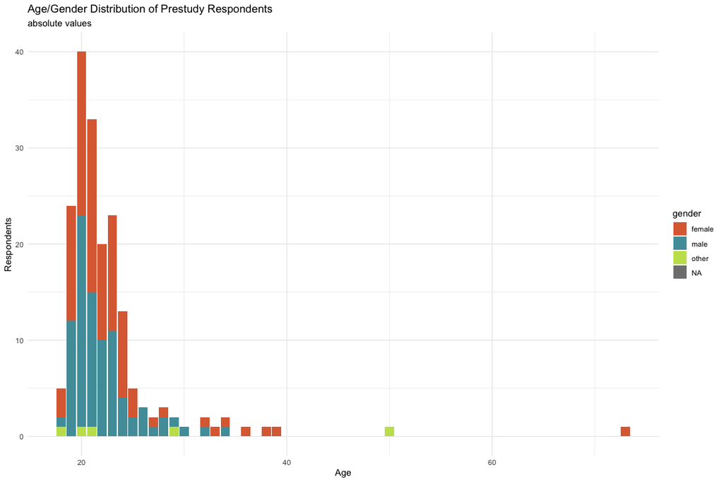

```r
data_age_gender = resp |>
    mutate(age = as.numeric(age)) |>
    count(age, gender) |>
    complete(age = 18:40, fill = list(n = 0))

ggplot(data_age_gender) +
  geom_bar(aes(x = age, y = n, fill = gender), stat = "identity") +
  theme_minimal() +
  labs(
    title = "Age/Gender Distribution of Prestudy Respondents",
    subtitle = "absolute values",
    x = "Age",
    y = "Respondents"
  ) +
  scale_fill_manual(values=c("#DD6C40", "#509DA9", "#C4E059"))
```

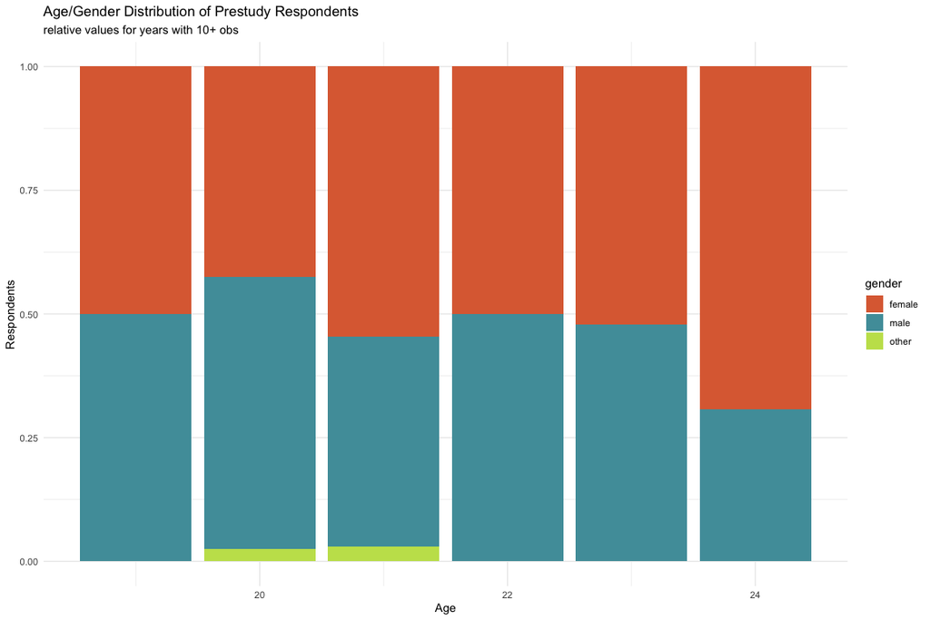

```r
ggplot(data_age_gender |> group_by(age) |> mutate(total_resp = sum(n)) |> filter(total_resp >= 10))+
  geom_bar(aes(x = age, y = n, fill = gender), stat = "identity", position = "fill") +
  theme_minimal() +
  labs(
    title = "Age/Gender Distribution of Prestudy Respondents",
    subtitle = "relative values for years with 10+ obs",
    x = "Age",
    y = "Respondents"
  ) +
  scale_fill_manual(values=c("#DD6C40", "#509DA9", "#C4E059"))
```

Maybe it’s make sense to replace gender “other” to non-binary in plots:

```r
resp |>
  filter(gender == "other") |>
  select(gender_oth) |>
  head()
```

```
## # A tibble: 5 × 1
##   gender_oth
##   <chr>
## 1 ""
## 2 "Ikkje-binær"
## 3 "Non-binary"
## 4 "non binary (i think lol)"
## 5 "otger"
```

### Departments & Institutes

We still have majority of students from ex-MATNAT, and 0 respondents from Medicine and Law Faculties:

```r
data_inst_dep = resp |>
  group_by(institute, subj) |>
  count() |>
  full_join(institute_lookup, by = c("institute", "subj" = "dep")) |>
  mutate(n = ifelse(is.na(n), 0, n))

cutiepie = c("Faculty of Fine Art, Music and Design" = "#9A3FE5", "Faculty of Humanities" = "#D5CC4A", "Faculty of Law" = "#B73737", "Faculty of Mathematics and Natural Sciences" = "#2C968C", "Faculty of Medicine" = "#55DB46", "Faculty of Psychology" = "#3E63B3", "Faculty of Social Sciences" = "#C48E43")


institue_color = data_inst_dep |>
  group_by(institute) |>
  count() |>
  cbind(color = cutiepie) |>  # 7 institutes 7 colors
  select(-n)

dep_color_palette_vector = generate_department_colors(data_inst_dep, institue_color)
dep_color_palette = data.frame(Name = names(dep_color_palette_vector), Value = dep_color_palette_vector, stringsAsFactors = FALSE, row.names = NULL)
data_inst_dep = data_inst_dep |>
  left_join(dep_color_palette, by = c("subj" = "Name")) |>
  mutate(institute_subj = interaction(institute, subj, sep = ": ")) |>
  arrange(institute_subj)
```

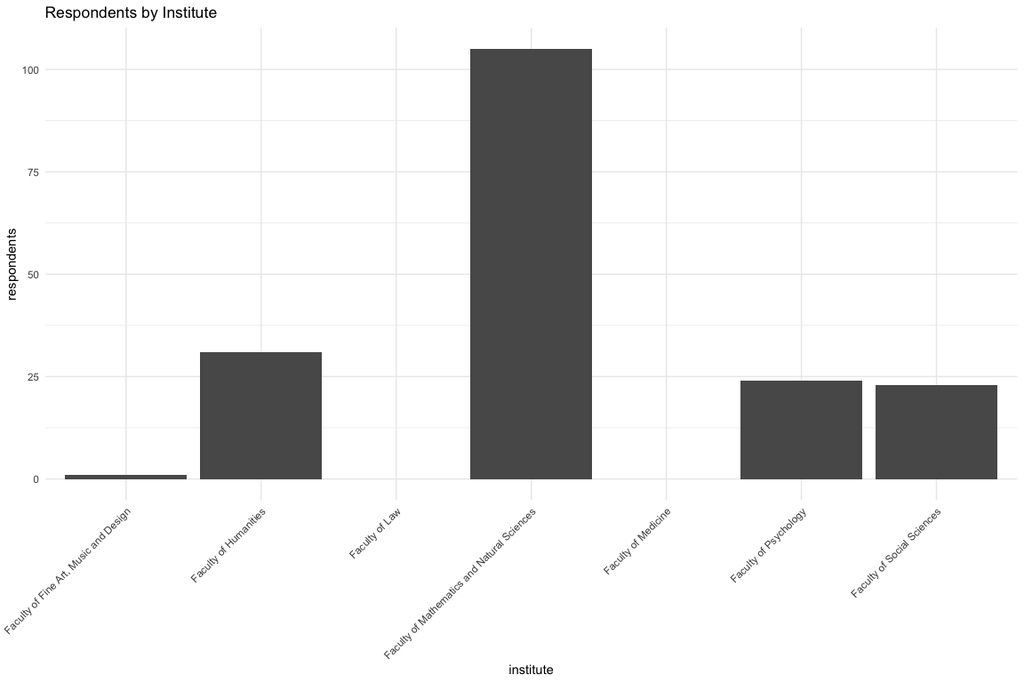

```r
data_inst_dep  |>
  ggplot() +
  geom_bar(aes(x = institute, y = n), stat = "identity") +
  theme_minimal() +
  labs(
    title = "Respondents by Institute",
    fill = "Department",
    x = "institute",
    y = "respondents"
  ) +
  theme(axis.text.x = element_text(angle = 45, hjust = 1, vjust = 1))
```

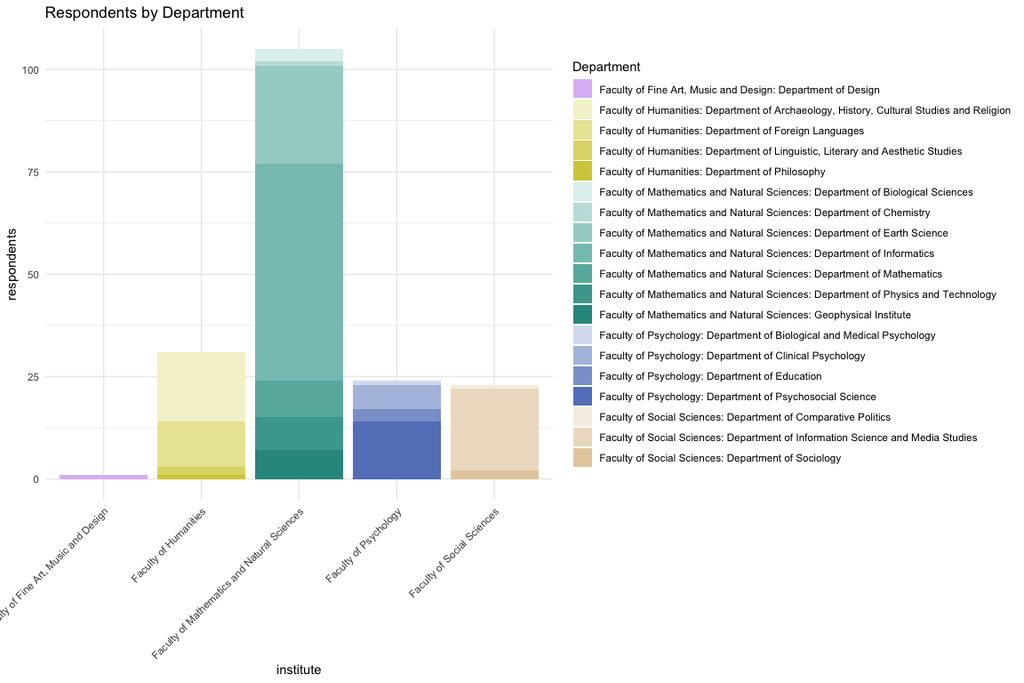

```r
data_inst_dep_nonull = data_inst_dep  |>
  filter(n>0)
data_inst_dep_nonull |>
  ggplot() +
  geom_bar(aes(x = institute, y = n, fill = institute_subj), stat = "identity") +
  theme_minimal() +
  labs(
    title = "Respondents by Department",
    fill = "Department",
    x = "institute",
    y = "respondents"
  ) +
  theme(axis.text.x = element_text(angle = 45, hjust = 1, vjust = 1)) +
  scale_fill_manual(values = data_inst_dep_nonull$Value) +
  guides(fill = guide_legend(ncol = 1))
```

### Education Year

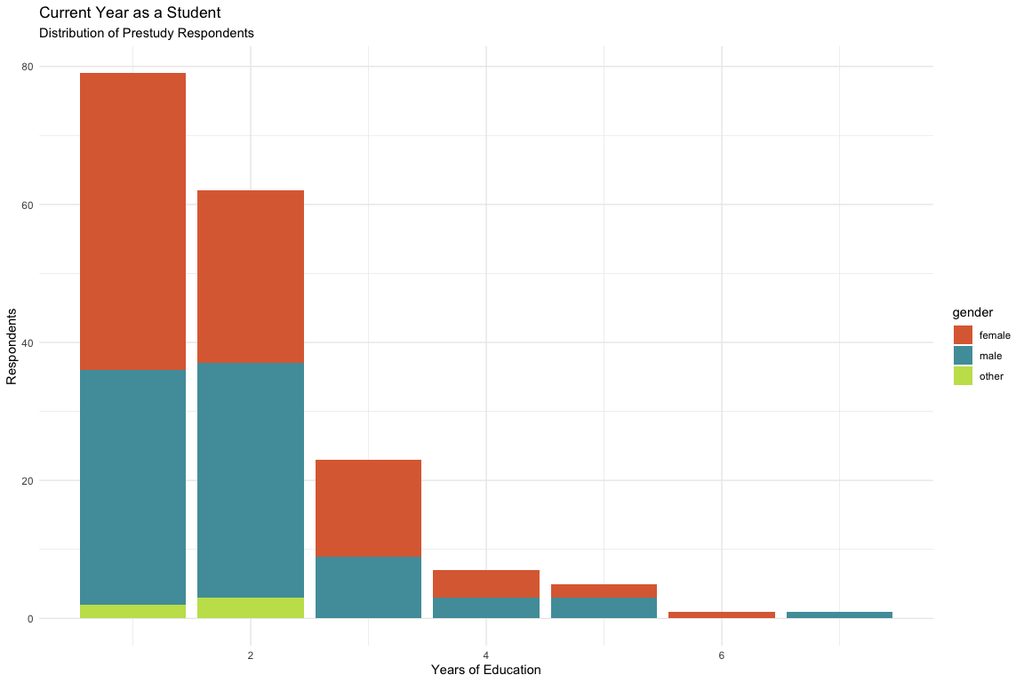

```r
data_edu_years = resp |>
  mutate(edu_year = as.numeric(edu_year)) |>
  group_by(gender, edu_year) |>
  count(edu_year) |>
  filter(edu_year < 10)

ggplot(data_edu_years) +
  geom_bar(aes(x = edu_year, y = n, fill = gender), stat = "identity") +
  theme_minimal() +
  labs(
    title = "Current Year as a Student",
    subtitle = "Distribution of Prestudy Respondents",
    x = "Years of Education",
    y = "Respondents"
  ) +
  scale_fill_manual(values=c("#DD6C40", "#509DA9", "#C4E059"))
```

### Occupation

This was a proxy on native / international student:

```r
cat(sum(resp$age == resp$occup), " ot of ", nrow(resp), " respondents lived in Norway the whole life (", round(sum(resp$age == resp$occup)/nrow(resp)*100,2), "%)", sep = "")
```

```
## 147 ot of 184 respondents lived in Norway the whole life (79.89%)
```

Only a small part of students are from abroad:

```r
resp_no_full_norw = resp |>
  filter(age != occup) |>
  select(age, occup) |>
  mutate(
    age = as.numeric(age),
    occup = as.numeric(occup),
    diff = age - occup) |>
  filter(diff > 0)

resp_no_full_norw |>
  summarise(average_age_occup_differnece = mean(diff))
```

```
## # A tibble: 1 × 1
##   average_age_occup_differnece
##                          <dbl>
## 1                         12.0
```

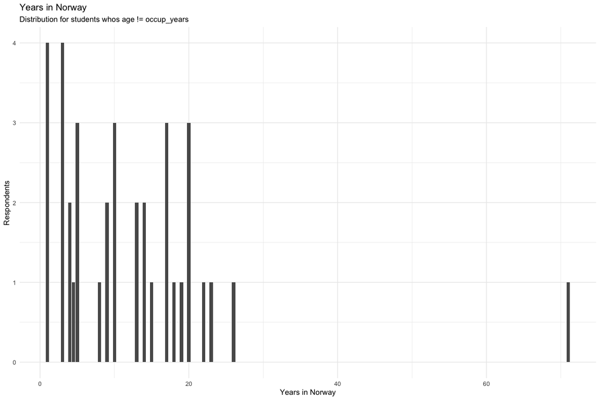

```r
ggplot(resp_no_full_norw) +
  geom_bar(aes(x = occup)) +
  theme_minimal() +
  labs(
    title = "Years in Norway",
    subtitle = "Distribution for students whos age != occup_years",
    x = "Years in Norway",
    y = "Respondents"
  )
```

### First of the Family

Higher degree of family members can also correlate with the preformance, well-being, etc.

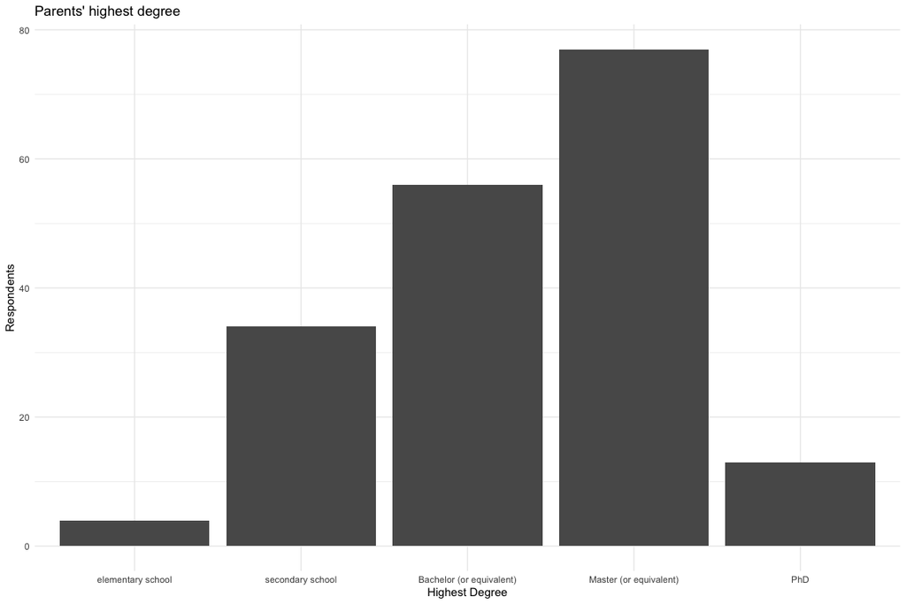

```r
data_family =  resp |>
  group_by(family_acad, institute) |>
  count() |>
  mutate(family_acad = factor(family_acad,
                                 levels = c(
                                   "elementary school",
                                   "secondary school" ,
                                   "Bachelor (or equivalent)",
                                   "Master (or equivalent)",
                                   "PhD")),
         institute = factor(institute,
                            levels = c("Faculty of Fine Art, Music and Design ", "Faculty of Humanities", "Faculty of Mathematics and Natural Sciences", "Faculty of Psychology", "Faculty of Social Sciences"))) |>
  left_join(institue_color, by = "institute")

ggplot(data_family) +
  geom_bar(aes(x = family_acad, y = n), stat = "identity") +
  theme_minimal() +
  labs(
    title = "Parents' highest degree",
    x = "Highest Degree",
    y = "Respondents"
  )
```

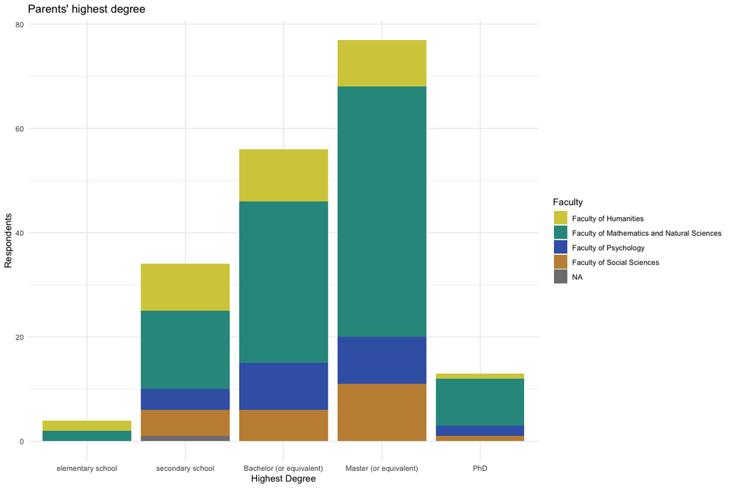

```r
data_family  |>
  arrange(institute) |>
  ggplot() +
    geom_bar(aes(x = family_acad, y = n, fill = institute), stat = "identity") +
    theme_minimal() +
    labs(
      title = "Parents' highest degree",
      x = "Highest Degree",
      y = "Respondents",
      fill = "Faculty"
    ) +
  scale_fill_manual(values = c(cutiepie[-3][-4], "black", "black", "black", "black"))
```

### Sexual Orientation

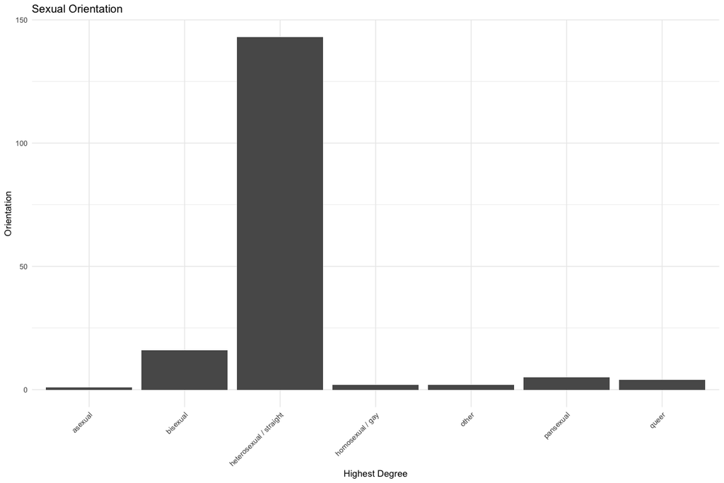

```r
data_so = resp |>
  filter(orient != "") |>
  group_by(orient) |>
  count()

ggplot(data_so) +
  geom_bar(aes(x = orient, y = n), stat = "identity") +
  theme_minimal() +
  labs(
    title = "Sexual Orientation",
    x = "Highest Degree",
    y = "Orientation"
  ) +
  theme(axis.text.x = element_text(angle = 45, hjust = 1, vjust = 1))
```

## 2. Responses Analysis

```r
# todo: filtering by amount of responses

topics_df = topics_df = read.csv('~/PhD/proj/code/pre-study/prestudy_app/prestudy_topics.csv')

scale_genderness = c("Completely Masculine", "Mostly Masculine", "Slightly Masculine", "Neutral", "Slightly Feminine", "Mostly Feminine", "Completely Feminine")
scale_familiarity = c("Not Familiar at All", "Slightly Familiar", "Moderately Familiar", "Very Familiar", "Highly Familiar")

evals = compose_df("evals") |>
  mutate(familiarity = factor(familiarity, levels = scale_familiarity),
         gender = factor(gender, levels = scale_genderness))

topics_long <- topics_df %>%
  pivot_longer(cols = c(cs, econ, lang),
               names_to = "field",
               values_to = "topic") %>%
  select(topic_subcategory, topic, field)

evals <- evals %>%
  left_join(topics_long, by = c("topic" = "topic")) |>
  mutate(topic = ifelse(is.na(topic_subcategory), topic, topic_subcategory),,
         field = ifelse(is.na(field), "base", field)) %>%
  select(-topic_subcategory)

head(evals)
```

```
##                                     id round assessment
## 1 034010ca-4d68-4856-afa9-4d7cf8bbb003     1          0
## 2 034010ca-4d68-4856-afa9-4d7cf8bbb003     1          0
## 3 034010ca-4d68-4856-afa9-4d7cf8bbb003     1          0
## 4 034010ca-4d68-4856-afa9-4d7cf8bbb003     1          0
## 5 034010ca-4d68-4856-afa9-4d7cf8bbb003     1          0
## 6 034010ca-4d68-4856-afa9-4d7cf8bbb003     1          0
##                       topic         familiarity               gender intime
## 1     Ocean Waves Formation     Highly Familiar              Neutral   TRUE
## 2                      Soda       Very Familiar              Neutral   TRUE
## 3                Smartphone     Highly Familiar     Mostly Masculine   TRUE
## 4 World Health Organization Moderately Familiar              Neutral   TRUE
## 5              Acne Product     Highly Familiar              Neutral   TRUE
## 6      Computer Simulations     Highly Familiar Completely Masculine   TRUE
##   field
## 1  base
## 2  base
## 3  base
## 4  base
## 5  base
## 6  base
```

- For gender perception evaluations, as expected, totally normal distribution:

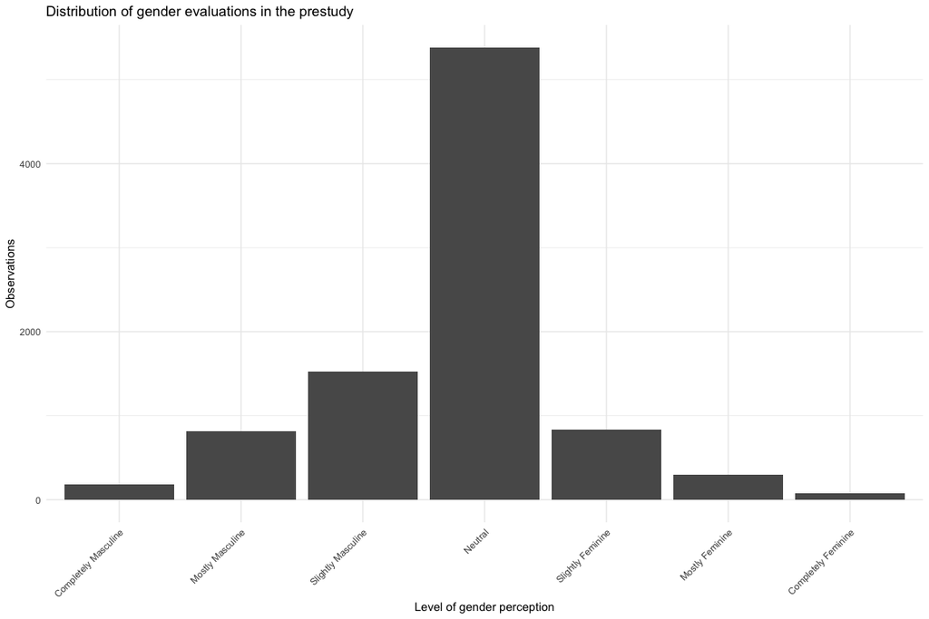

```r
evals |>
  group_by(gender_level = as.factor(gender)) |>
  count() |>
  ggplot() +
  geom_bar(aes(x = gender_level, y = n), stat = "identity") +
  theme_minimal() +
  labs(title = "Distribution of gender evaluations in the prestudy",
       x = "Level of gender perception",
       y = "Observations") +
  theme(axis.text.x = element_text(angle = 45, hjust = 1, vjust = 1))
```

- For familiarity evaluations, in contrast, there’s a more versatile distribution:

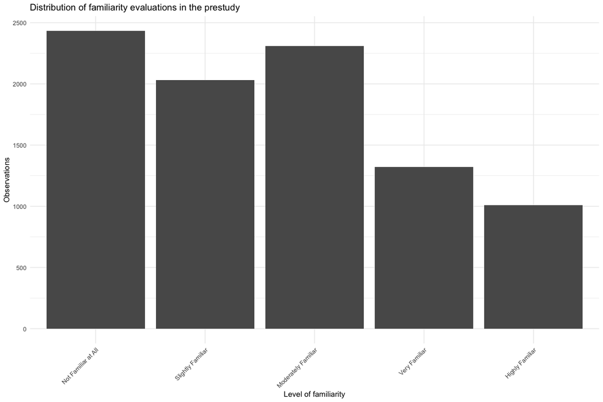

```r
evals |>
  group_by(fam_level = as.factor(familiarity)) |>
  count() |>
  ggplot() +
  geom_bar(aes(x = fam_level, y = n), stat = "identity") +
  theme_minimal() +
  labs(title = "Distribution of familiarity evaluations in the prestudy",
       x = "Level of familiarity",
       y = "Observations") +
  theme(axis.text.x = element_text(angle = 45, hjust = 1, vjust = 1))
```

```r
evals2 = evals |>
  mutate(gender = as.numeric(gender) - 4,
         familiarity = as.numeric(familiarity))
```

### Known Issues

#### Randomisation

Due to incorrect placement of `generate_topics()` function within the server, topics were generated in the same sample/order for all students of the current run, and changed only when the server was restarted.

```r
total_df = resp |>
  rename(sex = gender) |>
  mutate(sex = fct_recode(sex, "non binary"="other")) |>
  left_join(evals2, by="id") |>
  na.omit()
  #
ii = total_df |>
  filter(subj == 'Department of Informatics') |>
  group_by(topic, round) |>
  count() |>
    pivot_wider(
    names_from = round,
    values_from = n,
    names_prefix = "ii_round"
  )

matnat = total_df |>
  filter(institute == 'Faculty of Mathematics and Natural Sciences' & subj != 'Department of Informatics') |>
  group_by(topic, round) |>
  count() |>
    pivot_wider(
    names_from = round,
    values_from = n,
    names_prefix = "matnat_no_ii"
  )

other_inst = total_df |>
  filter(institute != 'Faculty of Mathematics and Natural Sciences') |>
  group_by(topic, round) |>
  count() |>
    pivot_wider(
    names_from = round,
    values_from = n,
    names_prefix = "oth_inst"
  )

occurences = topics_df |>
  select(topic_subcategory) |>
  left_join(ii, by = c('topic_subcategory' = 'topic')) |>
  left_join(matnat, by = c('topic_subcategory' = 'topic')) |>
  left_join(other_inst, by = c('topic_subcategory' = 'topic')) |>
  mutate(across(everything(), replace_na, 0)) |>
  group_by(topic_subcategory) |>
  mutate(total = sum(ii_round1, ii_round2, matnat_no_ii1, matnat_no_ii2, oth_inst1, oth_inst2)) |>
  arrange(-total) |>
  ungroup()
occurences |>
  gt() |>
  data_color(
  columns = vars(ii_round1, ii_round2, matnat_no_ii1, matnat_no_ii2, oth_inst1, oth_inst2),
  colors = scales::col_numeric(
    c("lightgrey", "green"),
    domain = c(0, 100)))
```

| topic_subcategory | ii_round1 | ii_round2 | matnat_no_ii1 | matnat_no_ii2 | oth_inst1 | oth_inst2 | total |
| --- | --- | --- | --- | --- | --- | --- | --- |
| Soda | 54 | 0 | 52 | 0 | 79 | 0 | 185 |
| Acne Product | 54 | 0 | 52 | 0 | 79 | 0 | 185 |
| Smartphone | 54 | 0 | 49 | 3 | 69 | 10 | 185 |
| World Health Organization | 54 | 0 | 52 | 0 | 79 | 0 | 185 |
| Ocean Waves Formation | 34 | 20 | 29 | 23 | 44 | 35 | 185 |
| Star Trek | 33 | 20 | 31 | 21 | 51 | 28 | 184 |
| Files Navigation in PC | 53 | 0 | 50 | 2 | 72 | 7 | 184 |
| Comic | 20 | 33 | 24 | 28 | 38 | 41 | 184 |
| Rock Paper Scissors | 20 | 33 | 22 | 30 | 31 | 48 | 184 |
| Board Games | 33 | 20 | 30 | 22 | 48 | 31 | 184 |
| Computer Simulations | 33 | 20 | 28 | 24 | 41 | 38 | 184 |
| Species Population Dynamics | 53 | 0 | 52 | 0 | 79 | 0 | 184 |
| Word Game | 53 | 0 | 50 | 2 | 72 | 7 | 184 |
| Fruits | 0 | 53 | 2 | 50 | 7 | 72 | 184 |
| Football Leagues and Rules | 53 | 0 | 51 | 1 | 76 | 3 | 184 |
| Elections | 33 | 20 | 31 | 21 | 51 | 28 | 184 |
| Gas Station | 53 | 0 | 52 | 0 | 79 | 0 | 184 |
| Turtle Navigation (Programming Basics) | 0 | 53 | 2 | 50 | 7 | 72 | 184 |
| Climatology | 20 | 33 | 22 | 30 | 31 | 48 | 184 |
| Rental Market | 53 | 0 | 51 | 1 | 76 | 3 | 184 |
| Healthcare Data | 53 | 0 | 52 | 0 | 79 | 0 | 184 |
| Pong (Game) | 20 | 33 | 24 | 28 | 38 | 41 | 184 |
| Driving Toll Fees | 53 | 0 | 49 | 3 | 69 | 10 | 184 |
| Sequences (Math) | 53 | 0 | 50 | 2 | 72 | 7 | 184 |
| Books Edition | 0 | 53 | 2 | 50 | 7 | 72 | 184 |
| Refraction (Optics) | 53 | 0 | 52 | 0 | 79 | 0 | 184 |
| Harry Potter | 53 | 0 | 49 | 3 | 69 | 10 | 184 |
| Poetry | 53 | 0 | 52 | 0 | 79 | 0 | 184 |
| Drug Testing | 53 | 0 | 49 | 3 | 69 | 10 | 184 |
| Vending Machine | 20 | 33 | 22 | 30 | 31 | 48 | 184 |
| Species Extinction | 0 | 53 | 3 | 49 | 10 | 69 | 184 |
| Frisbee Golf | 20 | 33 | 22 | 30 | 31 | 48 | 184 |
| Olympic Records | 0 | 53 | 1 | 51 | 3 | 76 | 184 |
| Projectile motion | 0 | 52 | 2 | 50 | 7 | 72 | 183 |
| Nim (Strategy game) | 20 | 32 | 23 | 29 | 35 | 44 | 183 |
| Hotels / Hospitality | 20 | 32 | 22 | 30 | 31 | 48 | 183 |
| Radio navigation | 0 | 52 | 2 | 50 | 7 | 72 | 183 |
| Bottled Water | 53 | 0 | 49 | 2 | 69 | 7 | 180 |
| Insurance | 33 | 20 | 30 | 21 | 48 | 28 | 180 |
| Snake | 20 | 33 | 21 | 30 | 28 | 48 | 180 |
| Dishwashing | 0 | 53 | 2 | 49 | 7 | 69 | 180 |
| Demography | 0 | 53 | 1 | 49 | 3 | 69 | 175 |
| Electricity Consumption | 33 | 20 | 28 | 22 | 41 | 31 | 175 |
| Food Delivery Order | 0 | 53 | 1 | 49 | 3 | 69 | 175 |
| Carpentry | 33 | 20 | 28 | 22 | 41 | 31 | 175 |
| Painting | 33 | 0 | 30 | 1 | 48 | 3 | 115 |
| Making a Sandwich | 33 | 0 | 29 | 2 | 44 | 7 | 115 |
| Meteorology | 33 | 0 | 31 | 0 | 51 | 0 | 115 |
| Strategic Planning | 0 | 32 | 3 | 28 | 10 | 41 | 114 |
| Pizza | 33 | 0 | 30 | 0 | 48 | 0 | 111 |
| Video Games | 20 | 0 | 23 | 1 | 35 | 3 | 82 |
| Tetris | 20 | 0 | 21 | 3 | 28 | 10 | 82 |
| Wordle | 0 | 20 | 0 | 24 | 0 | 38 | 82 |
| HR management | 0 | 19 | 3 | 21 | 10 | 28 | 81 |
| History of maths | 21 | 0 | 22 | 0 | 31 | 0 | 74 |

- we need to test hypothesis on the role of the context on topics that have enough observetions both in rounds 1 and 2.
  - if there’s an effect, that’s good
  - if there’s NO effect, we can combine both rounds and get more observations.

There are 17/55 topics with 20+ observations for each of the groups of interest:

```r
occurences_topics_1 = occurences |>
  filter_at(vars(-topic_subcategory), all_vars(. >=20)) |>
  select(topic_subcategory) |>
  unlist() |>
  array()

occurences |>
  filter_at(vars(-topic_subcategory), all_vars(. >=20)) |>
  gt() |>
  data_color(
  columns = vars(ii_round1, ii_round2, matnat_no_ii1, matnat_no_ii2, oth_inst1, oth_inst2),
  colors = scales::col_numeric(
    c("lightgrey", "green"),
    domain = c(0, 100)))
```

| topic_subcategory | ii_round1 | ii_round2 | matnat_no_ii1 | matnat_no_ii2 | oth_inst1 | oth_inst2 | total |
| --- | --- | --- | --- | --- | --- | --- | --- |
| Ocean Waves Formation | 34 | 20 | 29 | 23 | 44 | 35 | 185 |
| Star Trek | 33 | 20 | 31 | 21 | 51 | 28 | 184 |
| Comic | 20 | 33 | 24 | 28 | 38 | 41 | 184 |
| Rock Paper Scissors | 20 | 33 | 22 | 30 | 31 | 48 | 184 |
| Board Games | 33 | 20 | 30 | 22 | 48 | 31 | 184 |
| Computer Simulations | 33 | 20 | 28 | 24 | 41 | 38 | 184 |
| Elections | 33 | 20 | 31 | 21 | 51 | 28 | 184 |
| Climatology | 20 | 33 | 22 | 30 | 31 | 48 | 184 |
| Pong (Game) | 20 | 33 | 24 | 28 | 38 | 41 | 184 |
| Vending Machine | 20 | 33 | 22 | 30 | 31 | 48 | 184 |
| Frisbee Golf | 20 | 33 | 22 | 30 | 31 | 48 | 184 |
| Nim (Strategy game) | 20 | 32 | 23 | 29 | 35 | 44 | 183 |
| Hotels / Hospitality | 20 | 32 | 22 | 30 | 31 | 48 | 183 |
| Insurance | 33 | 20 | 30 | 21 | 48 | 28 | 180 |
| Snake | 20 | 33 | 21 | 30 | 28 | 48 | 180 |
| Electricity Consumption | 33 | 20 | 28 | 22 | 41 | 31 | 175 |
| Carpentry | 33 | 20 | 28 | 22 | 41 | 31 | 175 |

```r
occurences_topics_2 = occurences |>
  group_by(topic_subcategory) |>
  summarise(r1 = sum(ii_round1, matnat_no_ii1, oth_inst1),
            r2 = sum(ii_round2, matnat_no_ii2, oth_inst2)) |>
  filter_at(vars(-topic_subcategory), all_vars(. >=20)) |>
  select(topic_subcategory) |>
  unlist() |>
  array()

occurences |>
  group_by(topic_subcategory) |>
  summarise(r1 = sum(ii_round1, matnat_no_ii1, oth_inst1),
            r2 = sum(ii_round2, matnat_no_ii2, oth_inst2)) |>
  # filter_at(vars(-topic_subcategory), all_vars(. >=20)) |>
  gt() |>
  data_color(
  columns = vars(r1, r2),
  colors = scales::col_numeric(
    c("lightgrey", "green"),
    domain = c(0, 200)))
```

| topic_subcategory | r1 | r2 |
| --- | --- | --- |
| Acne Product | 185 | 0 |
| Board Games | 111 | 73 |
| Books Edition | 9 | 175 |
| Bottled Water | 171 | 9 |
| Carpentry | 102 | 73 |
| Climatology | 73 | 111 |
| Comic | 82 | 102 |
| Computer Simulations | 102 | 82 |
| Demography | 4 | 171 |
| Dishwashing | 9 | 171 |
| Driving Toll Fees | 171 | 13 |
| Drug Testing | 171 | 13 |
| Elections | 115 | 69 |
| Electricity Consumption | 102 | 73 |
| Files Navigation in PC | 175 | 9 |
| Food Delivery Order | 4 | 171 |
| Football Leagues and Rules | 180 | 4 |
| Frisbee Golf | 73 | 111 |
| Fruits | 9 | 175 |
| Gas Station | 184 | 0 |
| HR management | 13 | 68 |
| Harry Potter | 171 | 13 |
| Healthcare Data | 184 | 0 |
| History of maths | 74 | 0 |
| Hotels / Hospitality | 73 | 110 |
| Insurance | 111 | 69 |
| Making a Sandwich | 106 | 9 |
| Meteorology | 115 | 0 |
| Nim (Strategy game) | 78 | 105 |
| Ocean Waves Formation | 107 | 78 |
| Olympic Records | 4 | 180 |
| Painting | 111 | 4 |
| Pizza | 111 | 0 |
| Poetry | 184 | 0 |
| Pong (Game) | 82 | 102 |
| Projectile motion | 9 | 174 |
| Radio navigation | 9 | 174 |
| Refraction (Optics) | 184 | 0 |
| Rental Market | 180 | 4 |
| Rock Paper Scissors | 73 | 111 |
| Sequences (Math) | 175 | 9 |
| Smartphone | 172 | 13 |
| Snake | 69 | 111 |
| Soda | 185 | 0 |
| Species Extinction | 13 | 171 |
| Species Population Dynamics | 184 | 0 |
| Star Trek | 115 | 69 |
| Strategic Planning | 13 | 101 |
| Tetris | 69 | 13 |
| Turtle Navigation (Programming Basics) | 9 | 175 |
| Vending Machine | 73 | 111 |
| Video Games | 78 | 4 |
| Word Game | 175 | 9 |
| Wordle | 0 | 82 |
| World Health Organization | 185 | 0 |

```r
all(sort(occurences_topics_1) == sort(occurences_topics_2))
```

```
## [1] TRUE
```

```r
print(occurences_topics_1)
```

```
##  [1] "Ocean Waves Formation"   "Star Trek"
##  [3] "Comic"                   "Rock Paper Scissors"
##  [5] "Board Games"             "Computer Simulations"
##  [7] "Elections"               "Climatology"
##  [9] "Pong (Game)"             "Vending Machine"
## [11] "Frisbee Golf"            "Nim (Strategy game)"
## [13] "Hotels / Hospitality"    "Insurance"
## [15] "Snake"                   "Electricity Consumption"
## [17] "Carpentry"
```

- we possibly cannot perform the analysis over the institutes, (will see about this below)

#### Versioning

The versioning was not counted before `2024-10-11 16:25:40` [commit](https://git.app.uib.no/ii/did/sasha_prestudy/-/commit/a024deedc01d34c2cf22346d3590eee4f05526f4) due to mistake on application’s design side. More data to be gathered to find out whether the mistake can cause additional biases in data.

```r
df_act |>
  filter(action == "version") |>
  arrange(timestamp)
```

```
##              timestamp                                   id  action   value
## 1  2024-10-11 17:45:54 d10c248e-4ba8-442a-934a-06ba0089b7a3 version  radios
## 2  2024-10-13 18:16:08 6d728738-486a-4e3f-ba5a-771d63ff9f5c version  radios
## 3  2024-10-13 22:33:36 69a34f5c-193c-4043-a4e2-134c2ccb628f version  radios
## 4  2024-10-13 23:11:48 95ae07a9-900f-4490-bdb7-7a97001b6285 version  radios
## 5  2024-10-14 13:09:01 5cdd4c9e-55eb-4a7a-b0b2-8d864960eb4d version sliders
## 6  2024-10-14 13:09:12 af1d022d-f553-4411-ae71-d30ef8add541 version  radios
## 7  2024-10-14 13:09:34 0f111394-1137-4a49-9283-6e6587406944 version  radios
## 8  2024-10-14 13:09:35 b2905fdb-8e7d-4477-82a3-f600717e98c3 version  radios
## 9  2024-10-14 13:09:48 ada2aad5-2dd8-4cc9-8e53-dfc351d45daf version sliders
## 10 2024-10-14 13:10:23 e1570ce5-c412-4d5b-840a-4f8912bd7a5a version  radios
## 11 2024-10-14 13:10:53 df1d4dd4-207d-44d6-988c-40b948d6486e version sliders
## 12 2024-10-14 13:13:26 4f460d85-fcf6-43f8-a71a-f8c8fae10f19 version  radios
## 13 2024-10-14 14:07:31 8ca71a2e-50e4-463c-8c33-5b720d6e8c4c version sliders
```

### RQ1: Does the context of assessment implies a bias to familiarity / gendering of the topic?

- Seems like context of language studies makes everything bit less gender biased, so we can’t combine round1 and round2 data together.

```r
total_df |>
  filter(topic %in% occurences_topics_1 & field %in% c('base', 'lang')) |>
  group_by(topic, field) |>
  summarise(
    avg_fam = mean(familiarity),
    avg_gen = mean(gender),
    gen_eff = abs(avg_gen),
    obs = n()
  ) |>
  filter(obs > 10) |>
  gt(rowname_col = "field") |>
  data_color(
    columns = vars(avg_gen),
    colors = scales::col_numeric(
      c("#509DA9", "#ffeb84", "#DD6C40"),
      domain = c(-2.5, 0, 2)))
```

|  | avg_fam | avg_gen | gen_eff | obs |
| --- | --- | --- | --- | --- |
| Board Games |  |  |  |  |
| base | 3.522523 | -0.36936937 | 0.36936937 | 111 |
| lang | 2.565217 | -0.02898551 | 0.02898551 | 69 |
| Carpentry |  |  |  |  |
| base | 2.539216 | -0.88235294 | 0.88235294 | 102 |
| lang | 1.643836 | -0.49315068 | 0.49315068 | 73 |
| Climatology |  |  |  |  |
| base | 2.205479 | 0.36986301 | 0.36986301 | 73 |
| Comic |  |  |  |  |
| base | 2.987805 | -0.86585366 | 0.86585366 | 82 |
| Computer Simulations |  |  |  |  |
| base | 3.098039 | -0.93137255 | 0.93137255 | 102 |
| lang | 2.289855 | -0.59420290 | 0.59420290 | 69 |
| Elections |  |  |  |  |
| base | 3.234783 | -0.29565217 | 0.29565217 | 115 |
| lang | 2.304348 | -0.10144928 | 0.10144928 | 69 |
| Electricity Consumption |  |  |  |  |
| base | 2.784314 | -0.54901961 | 0.54901961 | 102 |
| Frisbee Golf |  |  |  |  |
| base | 2.739726 | -0.84931507 | 0.84931507 | 73 |
| lang | 2.039216 | -0.61764706 | 0.61764706 | 102 |
| Hotels / Hospitality |  |  |  |  |
| base | 3.068493 | 0.45205479 | 0.45205479 | 73 |
| lang | 2.425743 | 0.18811881 | 0.18811881 | 101 |
| Insurance |  |  |  |  |
| base | 2.567568 | -0.40540541 | 0.40540541 | 111 |
| Nim (Strategy game) |  |  |  |  |
| base | 1.256410 | -0.17948718 | 0.17948718 | 78 |
| Ocean Waves Formation |  |  |  |  |
| base | 1.925234 | -0.18691589 | 0.18691589 | 107 |
| Pong (Game) |  |  |  |  |
| base | 2.304878 | -0.50000000 | 0.50000000 | 82 |
| Rock Paper Scissors |  |  |  |  |
| base | 4.342466 | -0.08219178 | 0.08219178 | 73 |
| Snake |  |  |  |  |
| base | 3.101449 | -0.36231884 | 0.36231884 | 69 |
| Star Trek |  |  |  |  |
| base | 2.034783 | -1.15652174 | 1.15652174 | 115 |
| lang | 1.594203 | -1.01449275 | 1.01449275 | 69 |
| Vending Machine |  |  |  |  |
| base | 2.876712 | -0.35616438 | 0.35616438 | 73 |

- No consistent effect was found for economics and computer science context:

```r
total_df |>
  filter(topic %in% occurences_topics_1 & field %in% c('base', 'econ', 'cs')) |>
  group_by(topic, field) |>
  summarise(
    avg_fam = mean(familiarity),
    avg_gen = mean(gender),
    gen_eff = abs(avg_gen),
    obs = n()
  ) |>
  filter(obs > 10) |>
  gt(rowname_col = "field") |>
  data_color(
    columns = vars(avg_gen),
    colors = scales::col_numeric(
      c("#509DA9", "#ffeb84", "#DD6C40"),
      domain = c(-2.5, 0, 2)))
```

|  | avg_fam | avg_gen | gen_eff | obs |
| --- | --- | --- | --- | --- |
| Board Games |  |  |  |  |
| base | 3.522523 | -0.36936937 | 0.36936937 | 111 |
| Carpentry |  |  |  |  |
| base | 2.539216 | -0.88235294 | 0.88235294 | 102 |
| Climatology |  |  |  |  |
| base | 2.205479 | 0.36986301 | 0.36986301 | 73 |
| econ | 2.747748 | 0.29729730 | 0.29729730 | 111 |
| Comic |  |  |  |  |
| base | 2.987805 | -0.86585366 | 0.86585366 | 82 |
| cs | 2.490196 | -0.78431373 | 0.78431373 | 102 |
| Computer Simulations |  |  |  |  |
| base | 3.098039 | -0.93137255 | 0.93137255 | 102 |
| Elections |  |  |  |  |
| base | 3.234783 | -0.29565217 | 0.29565217 | 115 |
| Electricity Consumption |  |  |  |  |
| base | 2.784314 | -0.54901961 | 0.54901961 | 102 |
| cs | 2.144928 | -0.52173913 | 0.52173913 | 69 |
| Frisbee Golf |  |  |  |  |
| base | 2.739726 | -0.84931507 | 0.84931507 | 73 |
| Hotels / Hospitality |  |  |  |  |
| base | 3.068493 | 0.45205479 | 0.45205479 | 73 |
| Insurance |  |  |  |  |
| base | 2.567568 | -0.40540541 | 0.40540541 | 111 |
| cs | 1.884058 | -0.47826087 | 0.47826087 | 69 |
| Nim (Strategy game) |  |  |  |  |
| base | 1.256410 | -0.17948718 | 0.17948718 | 78 |
| econ | 1.342857 | -0.18095238 | 0.18095238 | 105 |
| Ocean Waves Formation |  |  |  |  |
| base | 1.925234 | -0.18691589 | 0.18691589 | 107 |
| econ | 1.826087 | -0.13043478 | 0.13043478 | 69 |
| Pong (Game) |  |  |  |  |
| base | 2.304878 | -0.50000000 | 0.50000000 | 82 |
| econ | 2.127451 | -0.44117647 | 0.44117647 | 102 |
| Rock Paper Scissors |  |  |  |  |
| base | 4.342466 | -0.08219178 | 0.08219178 | 73 |
| econ | 2.603604 | -0.17117117 | 0.17117117 | 111 |
| Snake |  |  |  |  |
| base | 3.101449 | -0.36231884 | 0.36231884 | 69 |
| cs | 2.862745 | -0.37254902 | 0.37254902 | 102 |
| Star Trek |  |  |  |  |
| base | 2.034783 | -1.15652174 | 1.15652174 | 115 |
| Vending Machine |  |  |  |  |
| base | 2.876712 | -0.35616438 | 0.35616438 | 73 |
| cs | 2.323529 | -0.37254902 | 0.37254902 | 102 |

## Bugfixing (DONT READ BELOW ITS ALL WRONG)

### What topics are mostly perceived as masculine or feminine?

There’s a slight shift in topics set to a be more masculine:

It also reflects on the most extreme topics: **first 11 masuline topic are more related to the gender than the 2nd femine topic**:

```r
# todo: add number of topic occurences in the prestudy
# todo: subsets of ii - scitek - others
# todo: gender split

evals2_avgs = evals2 |>
  filter(round == 1) |>
  group_by(topic) |>
  summarise(
    avg_fam = mean(familiarity),
    avg_gen = mean(gender),
    gen_eff = abs(avg_gen)
  )

evals2_avgs |>
  arrange(-gen_eff) |>
  head(30) |>
  select(-gen_eff) |>
  gt() |>
  data_color(
    columns = vars(avg_gen),
    colors = scales::col_numeric(
      c("#509DA9", "#ffeb84", "#DD6C40"),
      domain = c(-2.5, 0, 2))) |>
  cols_label(
    avg_fam = "avg.Familiarity",
    avg_gen = "avg.Gender Score"
  ) |>
  tab_header(
    title = md("Top 15 topics that are mostly perceived as masculine or feminine"),
    subtitle = "sorted by absolute values"
  )
```

sorted by absolute values

| topic | avg.Familiarity | avg.Gender Score |
| --- | --- | --- |
| Olympic Records | 3.500000 | -2.2500000 |
| Football Leagues and Rules | 2.601124 | -1.6123596 |
| Video Games | 3.298701 | -1.4155844 |
| Star Trek | 2.052632 | -1.1666667 |
| Gas Station | 3.230769 | -1.0494505 |
| Acne Product | 2.879781 | 1.0218579 |
| Radio navigation | 1.666667 | -1.0000000 |
| Computer Simulations | 3.108911 | -0.9504950 |
| Comic | 2.975309 | -0.8641975 |
| Carpentry | 2.514851 | -0.8613861 |
| Frisbee Golf | 2.736111 | -0.8472222 |
| Species Extinction | 3.153846 | -0.7692308 |
| Files Navigation in PC | 3.104046 | -0.7225434 |
| History of maths | 2.164384 | -0.6986301 |
| Drug Testing | 2.319527 | -0.5917160 |
| Painting | 2.918182 | 0.5818182 |
| Projectile motion | 1.444444 | -0.5555556 |
| Turtle Navigation (Programming Basics) | 1.555556 | -0.5555556 |
| Electricity Consumption | 2.762376 | -0.5445545 |
| Tetris | 3.279412 | -0.5441176 |
| Strategic Planning | 2.769231 | -0.5384615 |
| Pong (Game) | 2.320988 | -0.5061728 |
| Demography | 3.750000 | -0.5000000 |
| Hotels / Hospitality | 3.055556 | 0.4583333 |
| Driving Toll Fees | 2.360947 | -0.4497041 |
| Sequences (Math) | 2.797688 | -0.4450867 |
| Insurance | 2.581818 | -0.4272727 |
| Poetry | 2.714286 | 0.4175824 |
| HR management | 2.384615 | 0.3846154 |
| World Health Organization | 3.032787 | 0.3825137 |

Possible outcomes:

- as the topic list was generated entirely by males, it could be a design bias.
  - e.g. things that were percieved as masculine are usually more specific (olympic records, star trek) than those that were considered as feminine (hr management, poetry).
- maybe stimuli in psycology tend to be related with more protected class of students?

### Does the distribution of familiarity scores match gender perception?

There’s no correlation or effect of familiarity on gender scores.

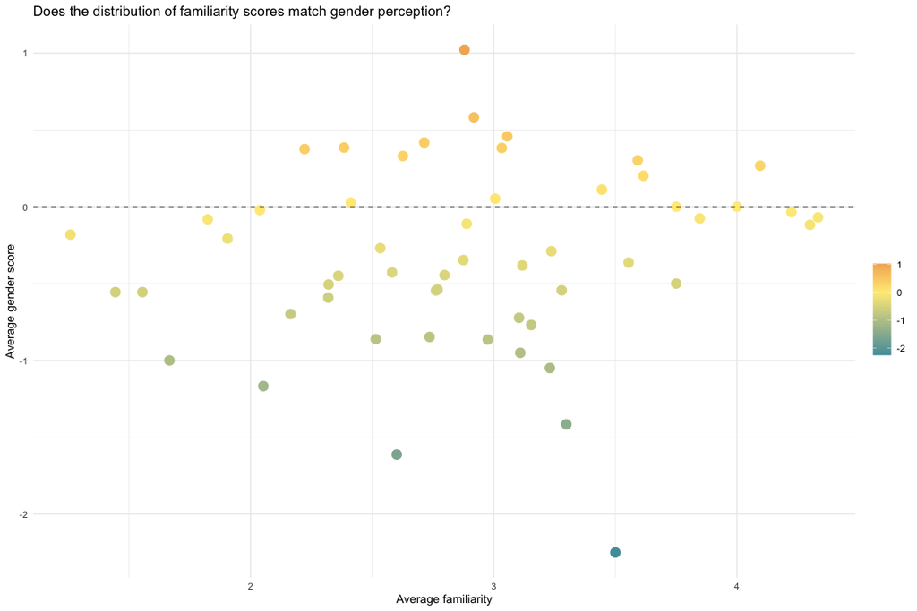

```r
ggplot(evals2_avgs) +
  geom_point(aes(x = avg_fam, y = avg_gen, color = avg_gen), size = 4) +
  geom_hline(yintercept = 0, linetype = "dashed", alpha = 0.5) +
  theme_minimal() +
  labs(
    title = "Does the distribution of familiarity scores match gender perception?",
    x = "Average familiarity",
    y = "Average gender score",
    color = ""
  ) +
  scale_color_gradient2(
    low = "#509DA9",
    mid = "#ffeb84",
    high = "#DD6C40",
    midpoint = 0
  )
```

```r
summary(lm(avg_gen ~ avg_fam, evals2_avgs))
```

```
##
## Call:
## lm(formula = avg_gen ~ avg_fam, data = evals2_avgs)
##
## Residuals:
##      Min       1Q   Median       3Q      Max
## -1.98641 -0.26049 -0.01099  0.37621  1.34657
##
## Coefficients:
##             Estimate Std. Error t value Pr(>|t|)
## (Intercept) -0.60855    0.32827  -1.854   0.0694 .
## avg_fam      0.09856    0.11038   0.893   0.3760
## ---
## Signif. codes:  0 '***' 0.001 '**' 0.01 '*' 0.05 '.' 0.1 ' ' 1
##
## Residual standard error: 0.5888 on 52 degrees of freedom
## Multiple R-squared:  0.0151, Adjusted R-squared:  -0.00384
## F-statistic: 0.7973 on 1 and 52 DF,  p-value: 0.376
```

- Students seem like hesitate to give extreme values to the topics even if they are familiar with it:

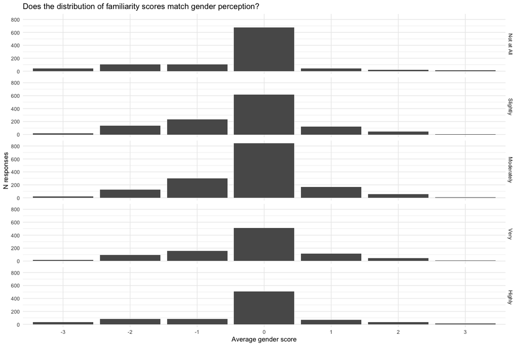

```r
evals2 |>
  filter(round == 1) |>
  mutate(familiarity = as.factor(familiarity),
         gender = as.factor(gender)) |>
  group_by(familiarity, gender) |>
  count() |>
  ggplot() +
    geom_bar(aes(x = gender, y = n), stat = "identity") +
    facet_grid(rows = vars(familiarity),
               labeller = as_labeller(c(`1` = "Not at All",
                                        `2` = "Slightly ",
                                        `3` = "Moderately ",
                                        `4` = "Very",
                                        `5` = "Highly"))) +
    theme_minimal() +
    labs(
      title = "Does the distribution of familiarity scores match gender perception?",
      x = "Average gender score",
      y = "N responses",

    ) +
    scale_color_gradient2(
      low = "#509DA9",
      mid = "#ffeb84",
      high = "#DD6C40",
      midpoint = 0
    )
```

### Do men and women differ in the extent to which they associate the topics with the certain gender?

```r
evals_sex = resp |>
  mutate(sex = as.factor(gender)) |>
  mutate(sex = fct_recode(sex, "non binary"="other")) |>
  select(id, sex) |>
  right_join(evals, by = "id")
```

No difference between genders in gender evaluations distribution:

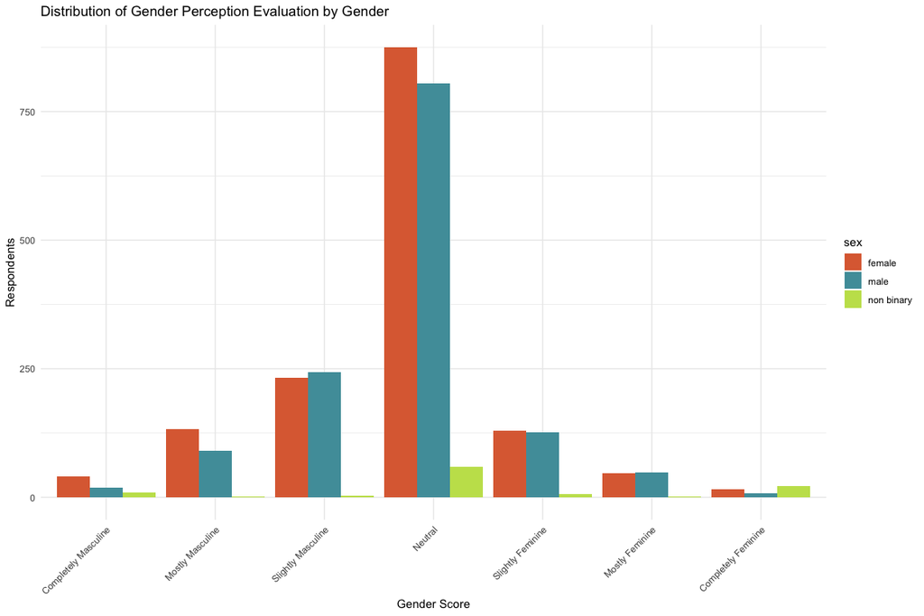

```r
evals_sex |>
  group_by(sex, familiarity, gender) |>
  count() |>
  na.omit() |>
  ggplot() +
  geom_bar(aes(x = gender, y = n, group = sex, fill = sex), stat = "identity", position = position_dodge()) +
  theme_minimal() +
  labs(
    title = "Distribution of Gender Perception Evaluation by Gender",
    # subtitle = "Distribution of Prestudy Respondents",
    x = "Gender Score",
    y = "Respondents"
  ) +
  scale_fill_manual(values=c("#DD6C40", "#509DA9", "#C4E059")) +
  theme(axis.text.x = element_text(angle = 45, hjust = 1, vjust = 1))
```

No significant difference between genders in familiarity distribution:

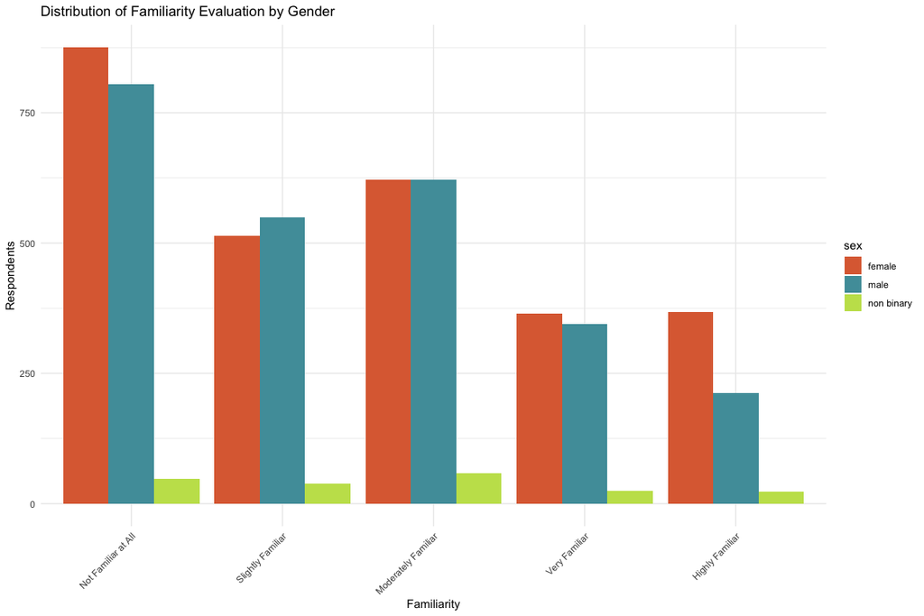

```r
evals_sex |>
  group_by(sex, familiarity, gender) |>
  count() |>
  na.omit() |>
  ggplot() +
  geom_bar(aes(x = familiarity, y = n, group = sex, fill = sex), stat = "identity", position = position_dodge()) +
  theme_minimal() +
  labs(
    title = "Distribution of Familiarity Evaluation by Gender",
    # subtitle = "Distribution of Prestudy Respondents",
    x = "Familiarity",
    y = "Respondents"
  ) +
  scale_fill_manual(values=c("#DD6C40", "#509DA9", "#C4E059")) +
  theme(axis.text.x = element_text(angle = 45, hjust = 1, vjust = 1))
```

```r
evals2sex = resp |>
  mutate(sex = as.factor(gender)) |>
  mutate(sex = fct_recode(sex, "non binary"="other")) |>
  select(id, sex) |>
  right_join(evals2, by = "id")
evals2sex_avg = evals2sex |>
  filter(round == 1) |>
  group_by(topic, sex) |>
  summarise(
    avg_fam = mean(familiarity),
    avg_gen = mean(gender),
    gen_eff = abs(avg_gen)
  ) |>
  na.omit()
evals2sex_avg
```

```
## # A tibble: 159 × 5
## # Groups:   topic [54]
##    topic         sex        avg_fam avg_gen gen_eff
##    <chr>         <fct>        <dbl>   <dbl>   <dbl>
##  1 Acne Product  female        3.32   1       1
##  2 Acne Product  male          2.41   1.09    1.09
##  3 Acne Product  non binary    2.4   -0.4     0.4
##  4 Board Games   female        3.74  -0.34    0.34
##  5 Board Games   male          3.35  -0.421   0.421
##  6 Board Games   non binary    3.25   0       0
##  7 Books Edition female        3.5    0.333   0.333
##  8 Books Edition male          2      0       0
##  9 Books Edition non binary    1     -3       3
## 10 Bottled Water female        3.86   0.214   0.214
## # ℹ 149 more rows
```

```r
evals2sex_avg |>
  arrange(-gen_eff) |>
  head(30) |>
  select(-gen_eff) |>
  gt(rowname_col = "sex") |>
  # tab_row_group(
  #   label = "Gender",
  #   rows = sex) |>
  data_color(
    columns = vars(avg_gen),
    colors = scales::col_numeric(
      c("#509DA9", "#ffeb84", "#DD6C40"),
      domain = c(-2.5, 0, 2)))
```

|  | avg_fam | avg_gen |
| --- | --- | --- |
| Books Edition |  |  |
| non binary | 1.000000 | -3.000000 |
| Dishwashing |  |  |
| non binary | 5.000000 | -3.000000 |
| Fruits |  |  |
| non binary | 1.000000 | -3.000000 |
| Projectile motion |  |  |
| non binary | 1.000000 | -3.000000 |
| Radio navigation |  |  |
| non binary | 1.000000 | -3.000000 |
| female | 1.666667 | -1.000000 |
| Species Extinction |  |  |
| non binary | 1.000000 | -3.000000 |
| Turtle Navigation (Programming Basics) |  |  |
| non binary | 1.000000 | 3.000000 |
| female | 1.500000 | -1.333333 |
| Olympic Records |  |  |
| female | 4.000000 | -2.333333 |
| male | 2.000000 | -2.000000 |
| Football Leagues and Rules |  |  |
| male | 2.952941 | -1.705882 |
| female | 2.288889 | -1.555556 |
| Video Games |  |  |
| female | 2.739130 | -1.521739 |
| male | 4.166667 | -1.333333 |
| Comic |  |  |
| non binary | 1.500000 | 1.500000 |
| Star Trek |  |  |
| female | 2.075472 | -1.226415 |
| male | 2.017241 | -1.172414 |
| Gas Station |  |  |
| female | 3.279570 | -1.172043 |
| male | 3.232558 | -1.011628 |
| Acne Product |  |  |
| male | 2.406977 | 1.093023 |
| female | 3.319149 | 1.000000 |
| Frisbee Golf |  |  |
| female | 2.674419 | -1.069767 |
| Computer Simulations |  |  |
| female | 2.863636 | -1.045455 |
| Demography |  |  |
| female | 3.666667 | -1.000000 |
| male | 4.000000 | 1.000000 |
| History of maths |  |  |
| non binary | 3.000000 | 1.000000 |
| Snake |  |  |
| non binary | 3.000000 | -1.000000 |
| Strategic Planning |  |  |
| non binary | 1.000000 | 1.000000 |
| Tetris |  |  |
| non binary | 3.000000 | -1.000000 |

```r
  # cols_label(
  #   avg_fam = "avg.Familiarity",
  #   avg_gen = "avg.Gender Score"
  # ) |>
  # tab_header(
  #   title = md("Top 15 topics that are mostly perceived as masculine or feminine"),
  #   subtitle = "sorted by absolute values"
  # )
```

### Departments and Institutes

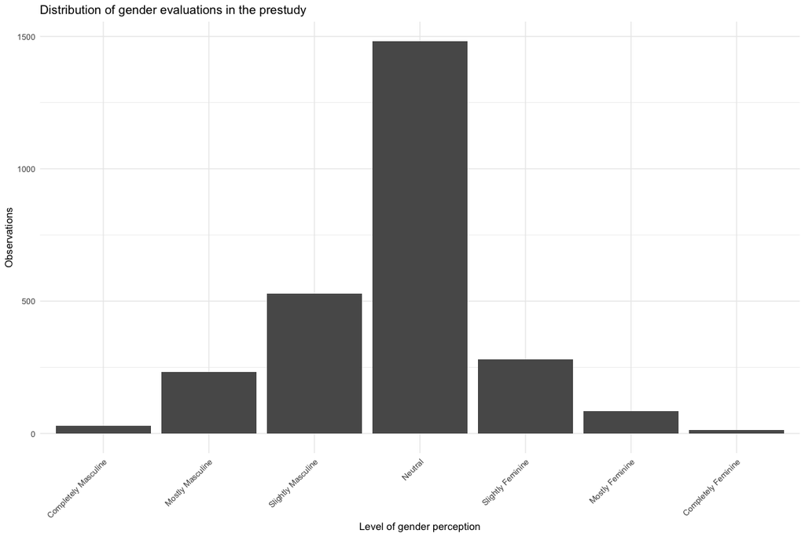

```r
evals |>
  left_join(select(resp, id, subj), by = "id") |>
  filter(subj == "Department of Informatics") |>
  group_by(gender_level = as.factor(gender)) |>
  count() |>
  ggplot() +
  geom_bar(aes(x = gender_level, y = n), stat = "identity") +
  theme_minimal() +
  labs(title = "Distribution of gender evaluations in the prestudy",
       x = "Level of gender perception",
       y = "Observations") +
  theme(axis.text.x = element_text(angle = 45, hjust = 1, vjust = 1))
```

— end of non valid —

```r
total_df |>
  group_by(topic, institute, subj) |>
  count()
```

```
## # A tibble: 998 × 4
## # Groups:   topic, institute, subj [998]
##    topic        institute                                   subj               n
##    <chr>        <chr>                                       <chr>          <int>
##  1 Acne Product Faculty of Fine Art, Music and Design       Department of…     1
##  2 Acne Product Faculty of Humanities                       Department of…    17
##  3 Acne Product Faculty of Humanities                       Department of…    11
##  4 Acne Product Faculty of Humanities                       Department of…     2
##  5 Acne Product Faculty of Humanities                       Department of…     1
##  6 Acne Product Faculty of Mathematics and Natural Sciences Department of…     3
##  7 Acne Product Faculty of Mathematics and Natural Sciences Department of…     1
##  8 Acne Product Faculty of Mathematics and Natural Sciences Department of…    24
##  9 Acne Product Faculty of Mathematics and Natural Sciences Department of…    54
## 10 Acne Product Faculty of Mathematics and Natural Sciences Department of…     9
## # ℹ 988 more rows
```